# Dürr et al. 2024

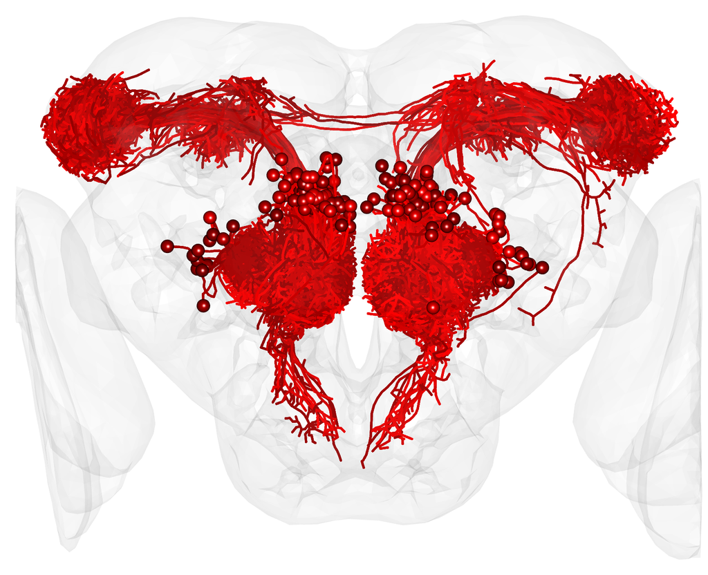

## Authors

Benedikt R. Dürr<sup>1,2</sup>, Enrico Bertolini <sup>1,3#</sup> , Suguru Takagi<sup>1#</sup>, Justine Pascual<sup>1,3#</sup>, Liliane Abuin<sup>1</sup>, Giovanna Lucarelli<sup>1</sup>, Richard Benton<sup>1</sup>, and Thomas O. Auer<sup>1,3</sup>*

1. Center for Integrative Genomics Faculty of Biology and Medicine, University of Lausanne CH-1015 Lausanne Switzerland
2. Current address: Centre for Organismal Studies, Heidelberg University, DE-69120 Heidelberg Germany
3. Department of Biology, University of Fribourg, CH-1700 Fribourg Switzerland

   # equal contribution

   * Corresponding author: Thomas O. Auer E-mail: thomas.auer@unifr.ch

### 1 Libraries & Installation

- Collection of all necessary installations to be done before using the scipts
- Loads locations and necessary data into the work environment
- Load the libraries installed here in each Figure script

### 2 - Datasets Ours

- Here we apply CMTK Registration-files to each PN trace in our Dsec dataset
- We also bridge the traces between brain reference spaces and mirror them as necessary
- We also relabel and export traces into folders which are used for generating Figure panels

### 2 - Datasets Others

- Here we query, sort and prepare datasets relevant for our analysis

### 3 - Glomeruli

- Here we demonstrated an workflow to use Glomeruli Annotations created with the [Microscopy Image Browser](http://mib.helsinki.fi) instead of AMIRA

### 4 - ALPN Annotation

- Here we manually annotated neurons after using NBLAST

### Figures

- Here we combined all necessary code to reproduce R-based figure panels shown in the manuscript of Dürr et al. 2024
- We commented important sections to support readers